# MATH2319_Assignment_Part1

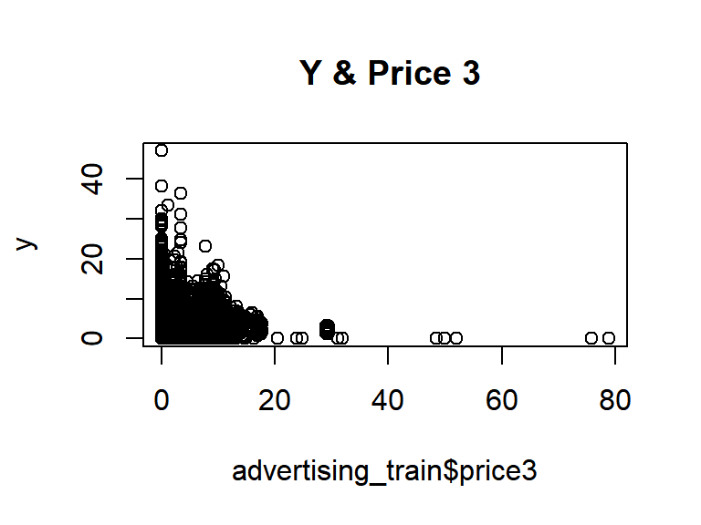

```r
plot(y~advertising_train$price3, main = " Y & Price 3")
```

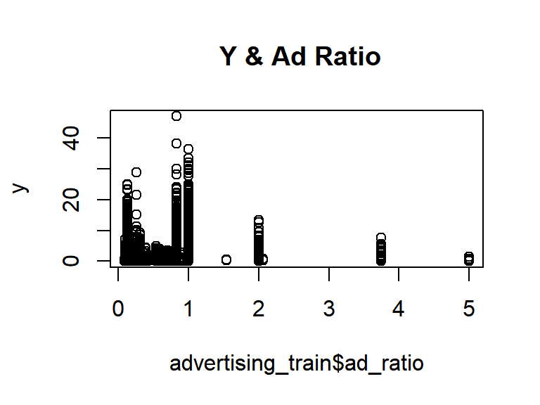

```r
plot(y~advertising_train$ad_ratio, main = " Y & Ad Ratio")
```

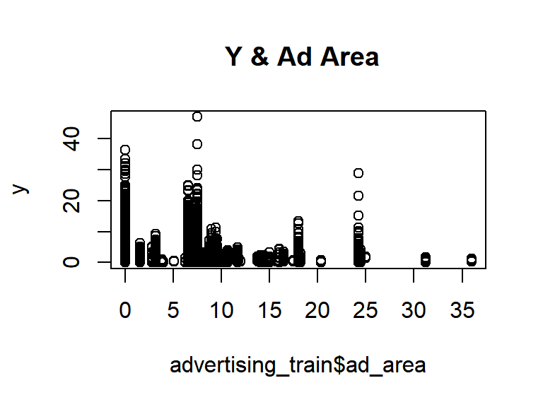

```r
plot(y~advertising_train$ad_area, main = " Y & Ad Area")
```

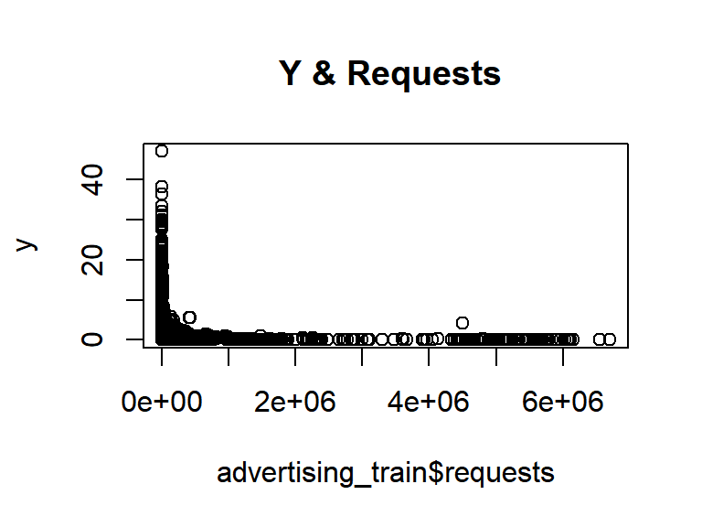

```r
plot(y~advertising_train$requests, main = " Y & Requests")
```

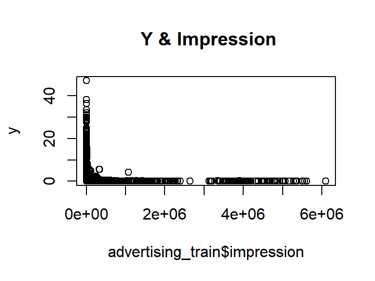

```r
plot(y~advertising_train$impression, main = " Y & Impression")
```

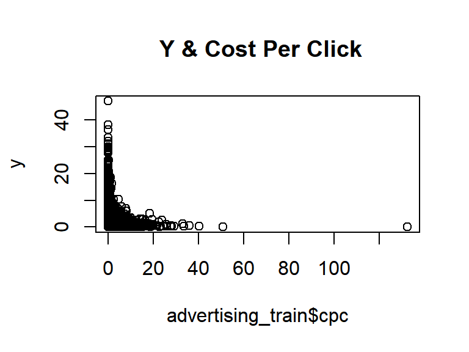

```r
plot(y~advertising_train$cpc, main = " Y & Cost Per Click")
```

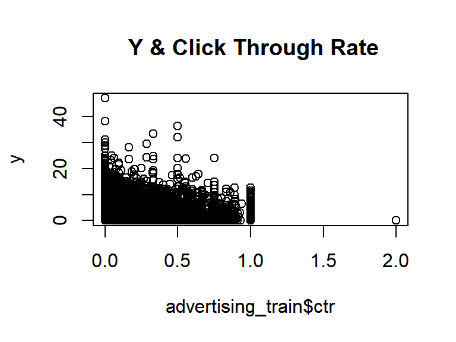

```r
plot(y~advertising_train$ctr, main = " Y & Click Through Rate")
```

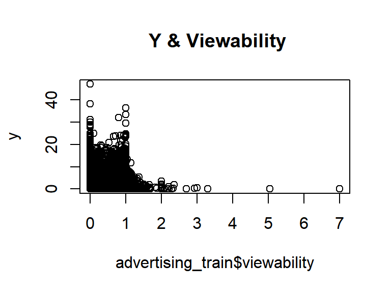

```r
plot(y~advertising_train$viewability, main = " Y & Viewability")
```

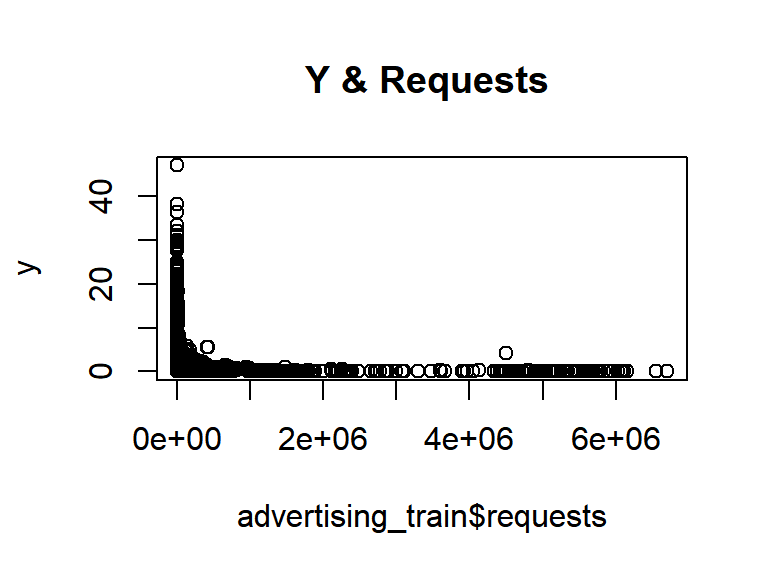

```r
plot(y~advertising_train$requests, main = " Y & Requests")
```

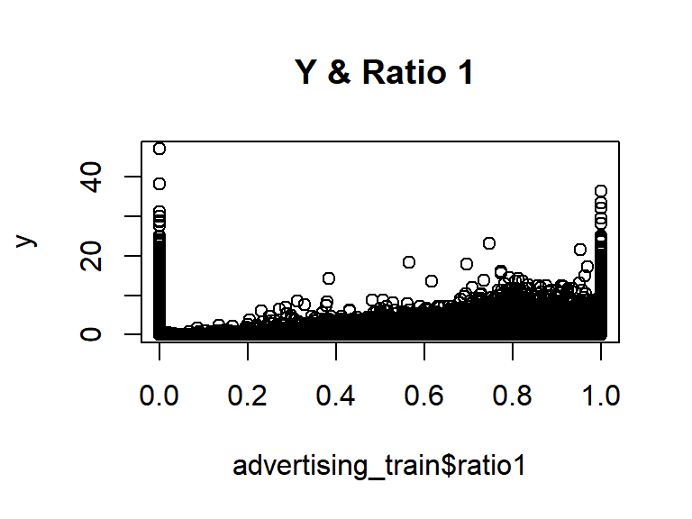

```r
plot(y~advertising_train$ratio1, main = " Y & Ratio 1")
```

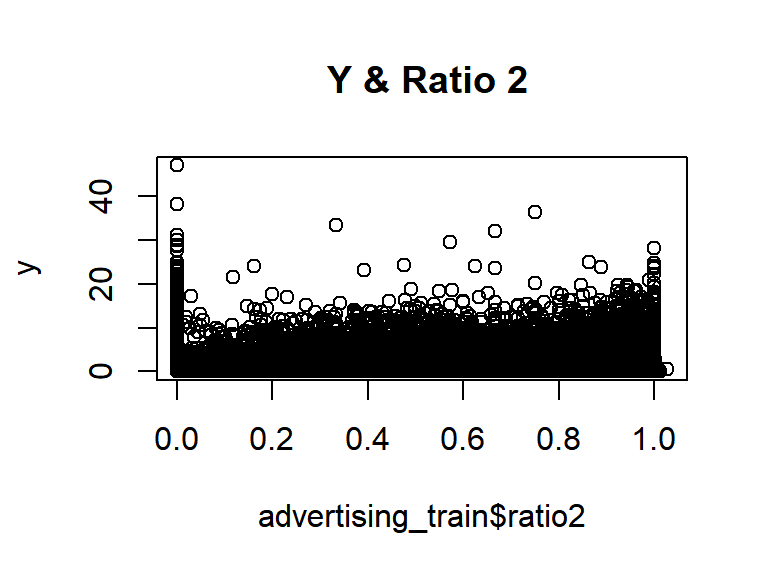

```r
plot(y~advertising_train$ratio2, main = " Y & Ratio 2")
```

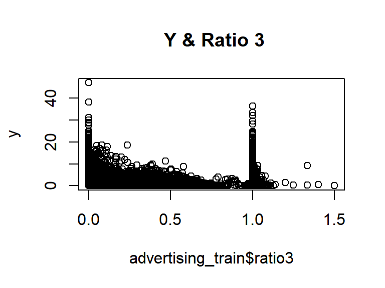

```r
plot(y~advertising_train$ratio3, main = " Y & Ratio 3")
```

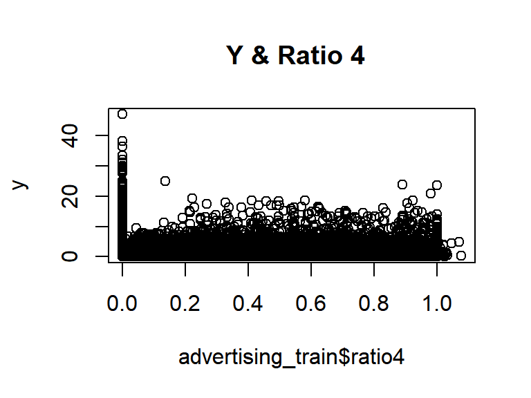

```r
plot(y~advertising_train$ratio4, main = " Y & Ratio 4")
```

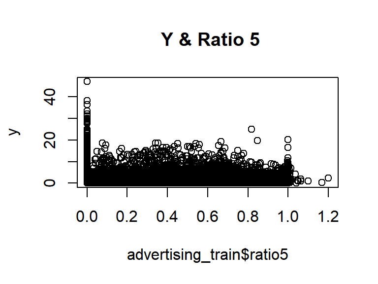

```r
plot(y~advertising_train$ratio5, main = " Y & Ratio 5")
```

# Visualisation

## Bivariate Visuals with Respect to Target Feature

### Prices

```r
#Calculate Average Price and Maximum Price
train1 <- train %>% mutate(avg_price = (price1*price2*price3)/3,
                           max_price = pmax(price1, price2, price3))
summary(train1$avg_price)
```

```
##      Min.   1st Qu.    Median      Mean   3rd Qu.      Max.
##    0.0000    0.0000    0.0001    4.8280    0.0374 1057.0340
```

```r
summary(train1$max_price)
```

```
##    Min. 1st Qu.  Median    Mean 3rd Qu.    Max.
##  0.0000  0.0000  0.2948  0.9328  0.9864 78.9000
```

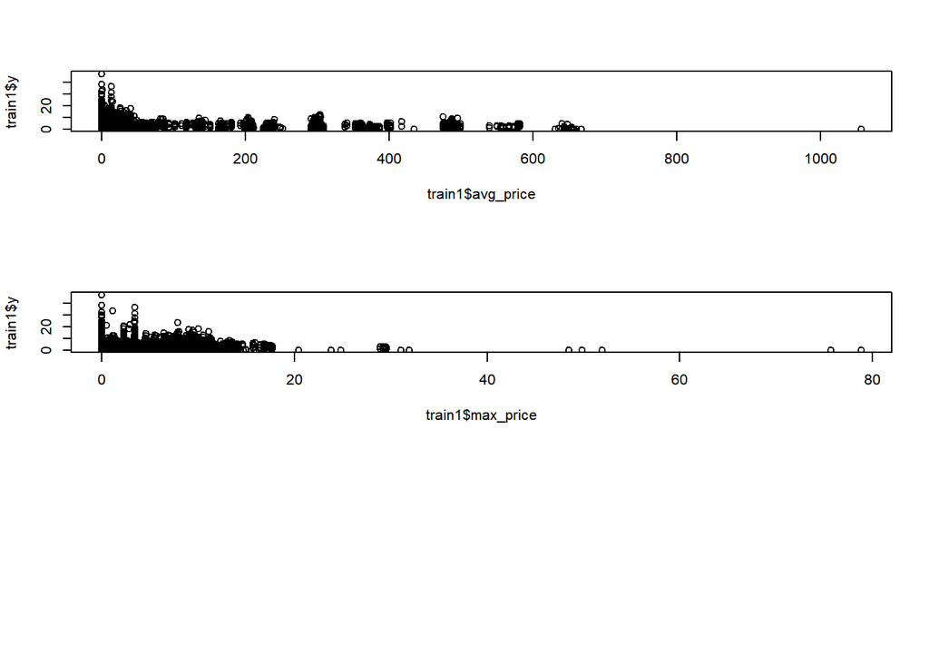

```r
par(mfrow = c(3,1))
plot(train1$avg_price, train1$y)
plot(train1$max_price, train1$y)
par(mfrow = c(1,1))
```

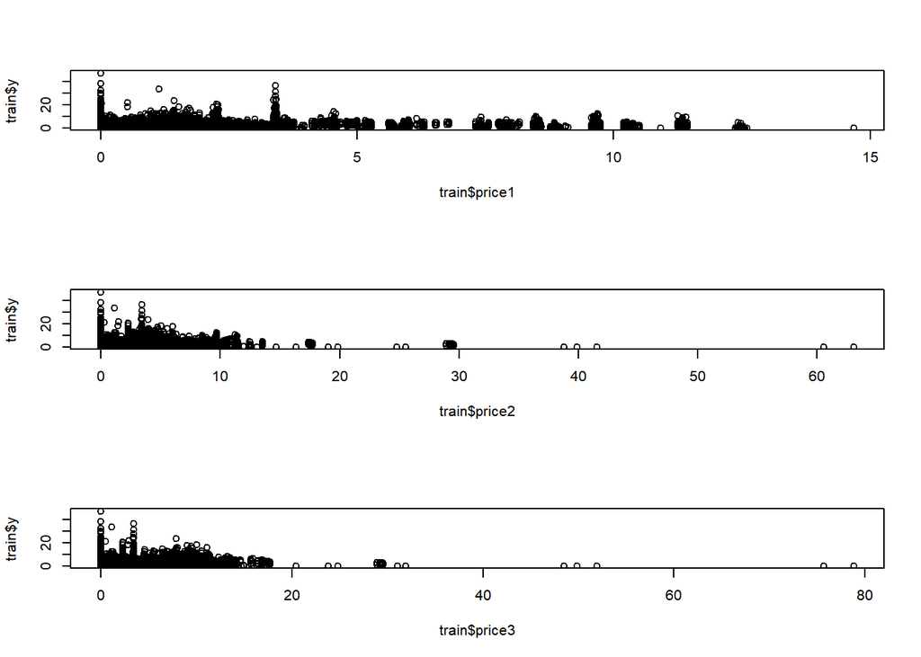

```r
# Price Data Comparison
par(mfrow = c(3,1))
plot(train$price1, train$y) # all pos skewed, majority at lower quartile of range, trace values at upper 3 quartiles
plot(train$price2, train$y)
plot(train$price3, train$y)
```

```r
par(mfrow = c(1,1))
```

### Ratios

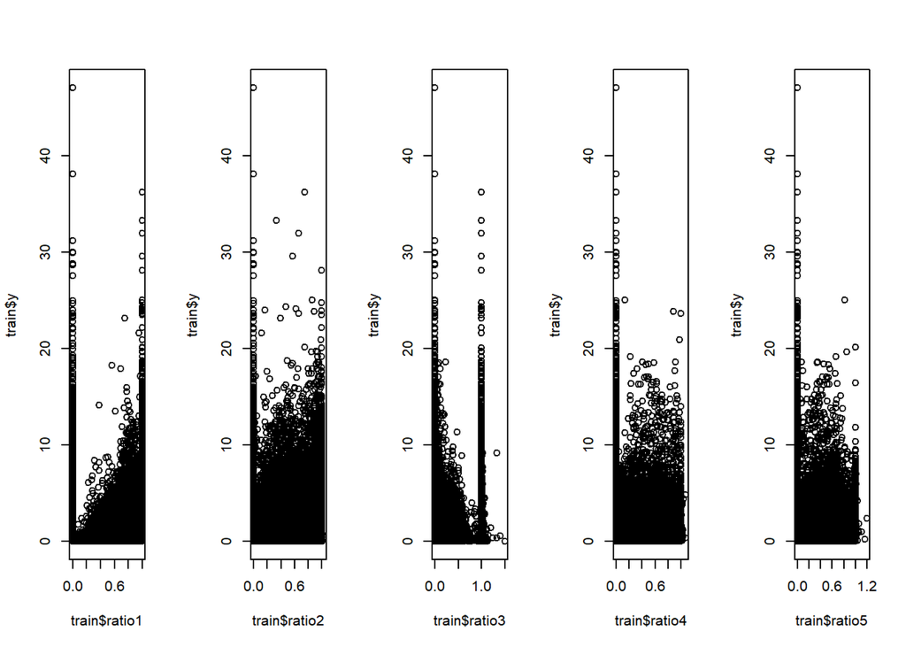

```r
# Ratio Data Comparison
par(mfrow = c(1,5))
plot(train$ratio1, train$y) # majority of variation at 0 and 1 ratios
plot(train$ratio2, train$y) # majority of variation at 0 and 1 ratios
plot(train$ratio3, train$y) # majority of variation at 0 and 1 ratios, with some exceeding 1
plot(train$ratio4, train$y) # majority of variation at 0
plot(train$ratio5, train$y) # majority of variation at 0 and some at 1 ratios, with some exceeding 1
```

```r
par(mfrow = c(1,1))
```

### CPC and CTR

Cost Per Click (also known as PPC, Pay Per Click) and Click Through Rate will be investigated for impact on each other and on the target variable.

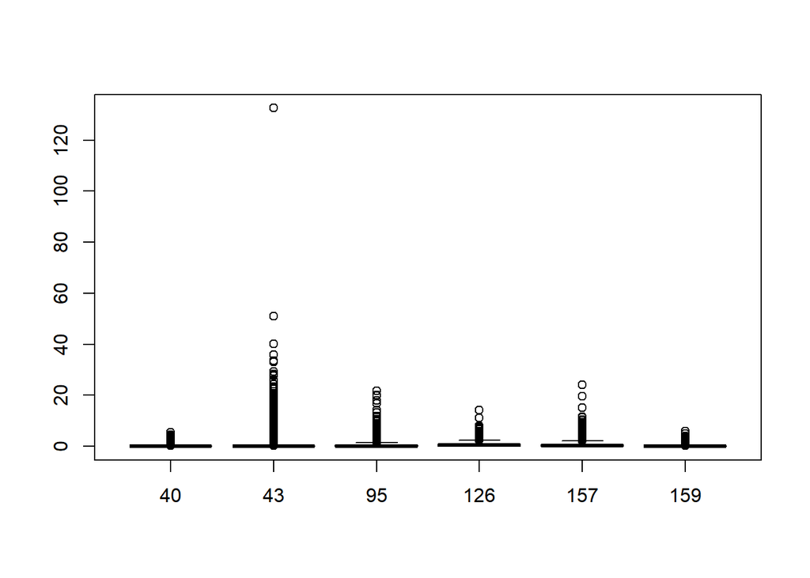

```r
# COST PER CLICKS
# This is the advertising cost per click for given ad, as price goes up, the 'rank' of the ad decreases exponentially.
# Essentially, you want to minimise cost per click, which reflects your score, visa versa.
cpc_id_box <- boxplot(cpc ~ companyId, data = train)
```

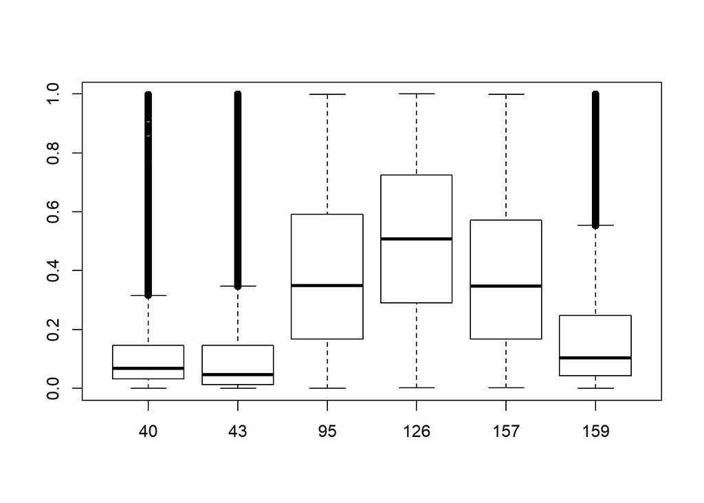

```r
cpc_filt <- train %>% select(companyId, cpc) %>%  filter(cpc > 0 & cpc < 1)
cpc_filt_box <- boxplot(cpc ~ companyId, data = cpc_filt) # company makes a difference
```

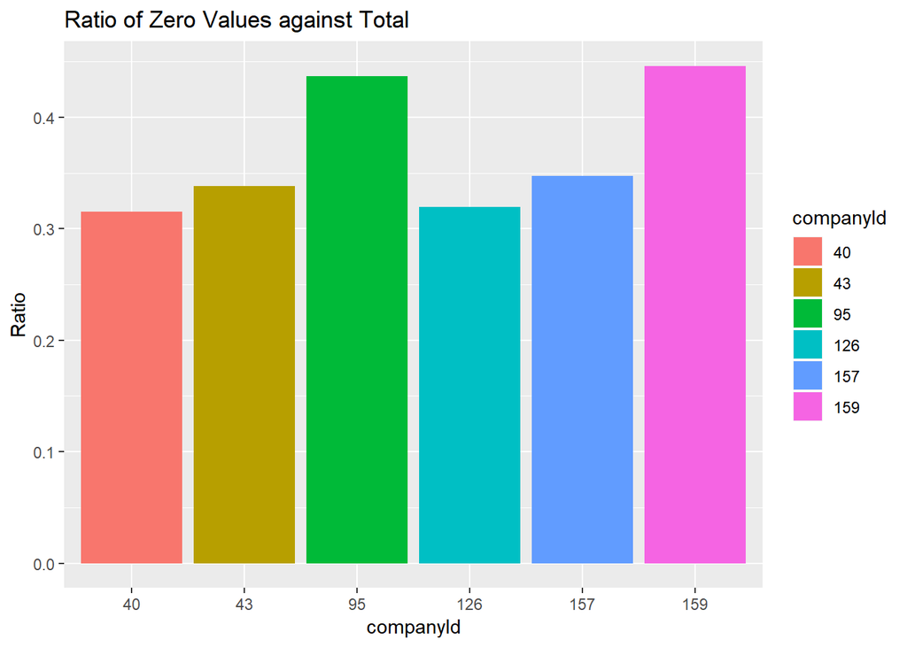

```r
cpc_zero <- train %>% select(companyId, cpc) %>%  group_by(companyId) %>% filter(cpc == 0) %>%  summarise(ZeroVal = n())
cpc_more <- train %>% select(companyId, cpc) %>%  group_by(companyId) %>%  summarise(Total = n())
cpc_tbl <- cbind(cpc_zero, cpc_more[2]) %>%  as.tbl %>%  mutate(Ratio = ZeroVal / Total,
                                                                NonZero = Total - ZeroVal)
# RATIO OF ZERO CPC TO TOTAL
ggplot(data = cpc_tbl,
       mapping = aes(y = Ratio, x = companyId, fill = companyId)) +
  geom_bar(stat = 'identity', position = 'dodge') +
  labs(title = 'Ratio of Zero Values against Total')
```

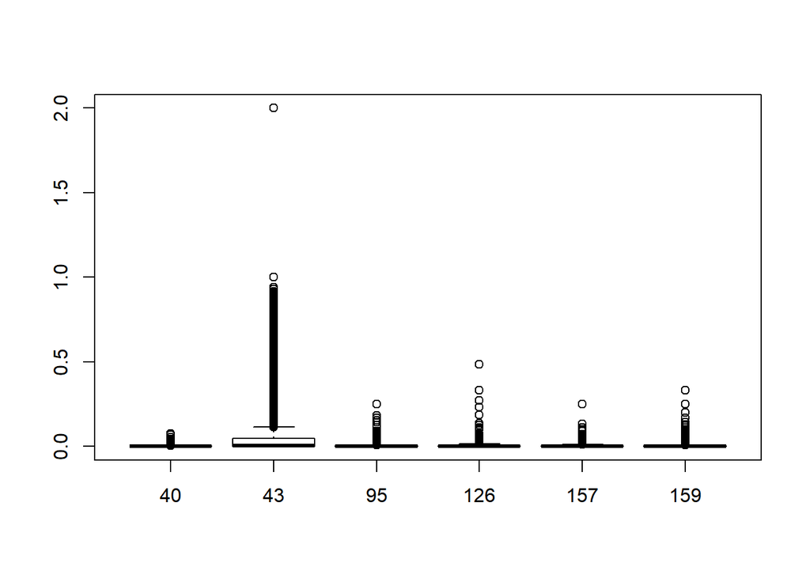

```r
# CLICK THROUGH RATE
# Perecentage of viewers on a web page who selected a hyperlink to a site
# CTR = (Total Measured Clicks/Total Measured Ad Impressions) * 100
# Clicks are per click, ad impression is the appearance of an ad (clicked or not)
ctr_id_box <- boxplot(ctr ~ companyId, data = train)
```

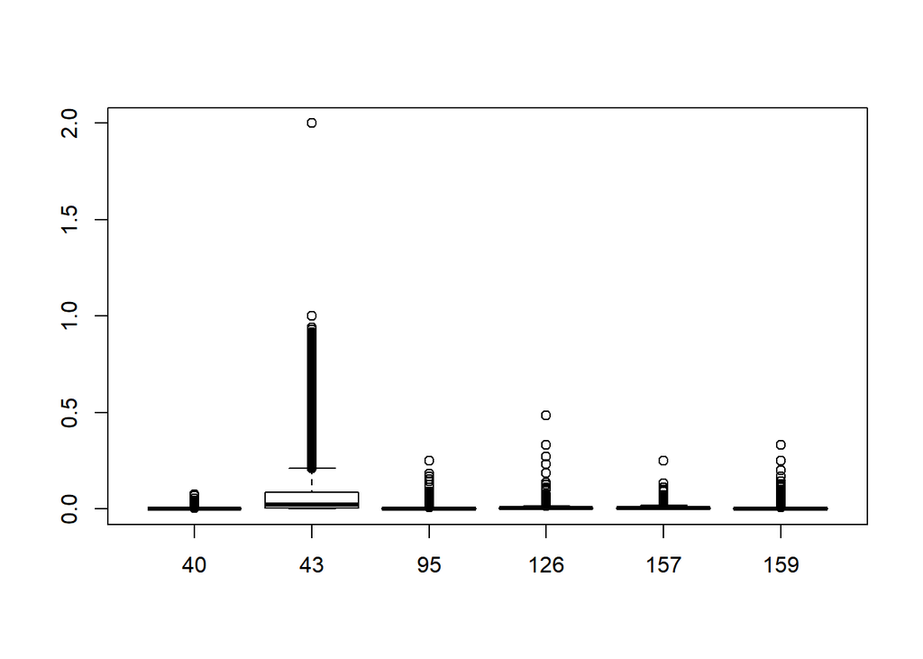

```r
ctr_filt <- train %>%  select(companyId, ctr) %>%  filter(ctr > 0)
ctr_filt_box <- boxplot(ctr ~ companyId, data = ctr_filt) # many 0 values for ID 43
```

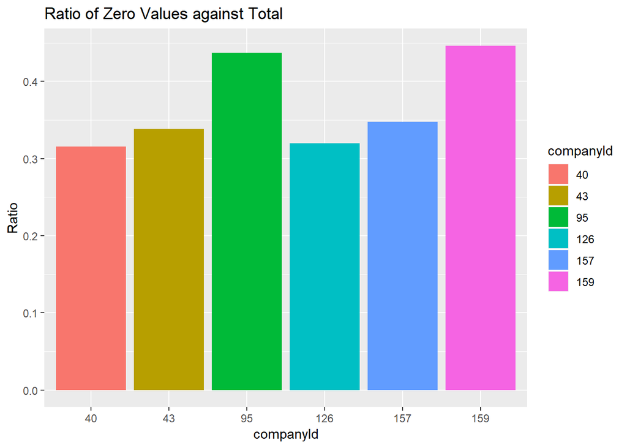

```r
ctr_zero <- train %>%  select(companyId, ctr) %>% group_by(companyId) %>% filter(ctr == 0) %>%  summarise(ZeroVal = n())
ctr_more <- train %>%  select(companyId, ctr) %>%  group_by(companyId) %>% summarise(Total = n())
ctr_tbl <- cbind(ctr_zero, ctr_more[2]) %>%  as.tbl %>%  mutate(Ratio = ZeroVal / Total,
                                                                NonZero = Total - ZeroVal)
# RATIO OF ZERO CTR TO TOTAL
ggplot(data = ctr_tbl,
       mapping = aes(y = Ratio, x = companyId, fill = companyId)) +
  geom_bar(stat = 'identity', position = 'dodge') +
  labs(title = 'Ratio of Zero Values against Total') # absolutely no difference to
```

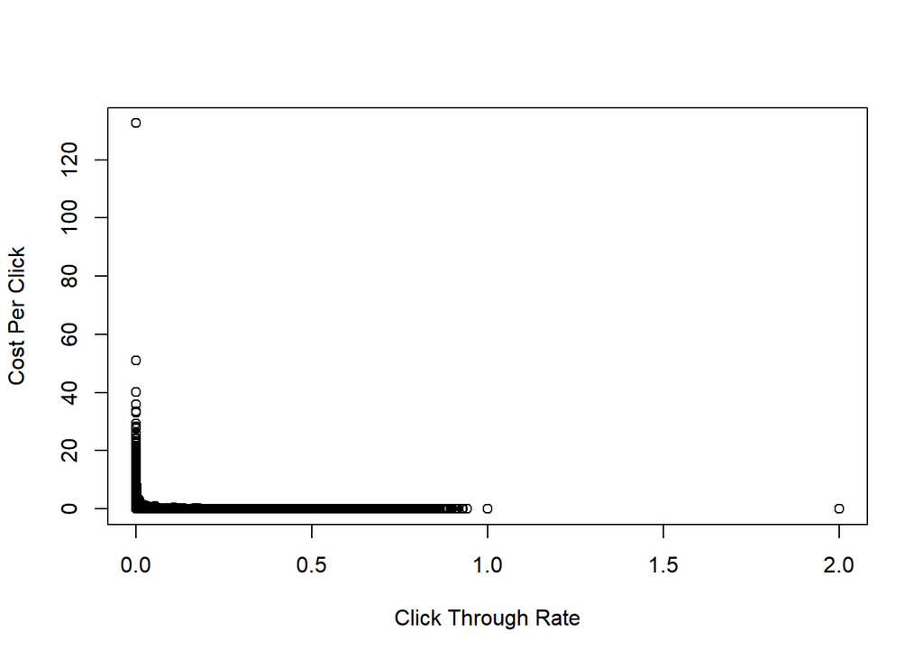

```r
# CPC against CTR
plot(cpc ~ ctr, data = train,
     ylab = 'Cost Per Click',
     xlab = 'Click Through Rate')
```

```r
# CTR decreases to nothing, the less appealing the ad, the more likely the the advertiser is charged higher for the less appealing ad
```

```r
# Bivariate analysis of partitioned data with respect to Target Feature y
# CTR Summary
ctrzero_y <- train %>% select(companyId, ctr, y) %>%  filter(ctr == 0)
summary(ctrzero_y)
```

```
##  companyId        ctr          y
##  40 : 3703   Min.   :0   Min.   : 0.0001
##  43 :45569   1st Qu.:0   1st Qu.: 0.1255
##  95 : 8622   Median :0   Median : 0.3492
##  126:  589   Mean   :0   Mean   : 0.7599
##  157:  444   3rd Qu.:0   3rd Qu.: 0.8313
##  159:20030   Max.   :0   Max.   :47.0600
```

```r
ctrmore_y <- train %>% select(companyId, ctr, y) %>%  filter(ctr > 0)
summary(ctrmore_y)
```

```
##  companyId        ctr                y
##  40 : 8041   Min.   :0.00010   Min.   : 0.00019
##  43 :89086   1st Qu.:0.00200   1st Qu.: 0.17018
##  95 :11109   Median :0.00630   Median : 0.46254
##  126: 1255   Mean   :0.05215   Mean   : 0.89789
##  157:  833   3rd Qu.:0.04600   3rd Qu.: 1.03178
##  159:24847   Max.   :2.00000   Max.   :36.26667
```

```r
# all metrics (with exception of Max value) increase for y when looking at higher click through rates
# CPC Summary
cpczero_y <- train %>% select(companyId, cpc, y) %>%  filter(cpc == 0)
summary(cpczero_y)
```

```
##  companyId        cpc          y
##  40 : 3703   Min.   :0   Min.   : 0.0001
##  43 :45530   1st Qu.:0   1st Qu.: 0.1257
##  95 : 8622   Median :0   Median : 0.3496
##  126:  589   Mean   :0   Mean   : 0.7603
##  157:  444   3rd Qu.:0   3rd Qu.: 0.8317
##  159:20025   Max.   :0   Max.   :47.0600
```

```r
cpcmore_y <- train %>%  select(companyId, cpc, y) %>% filter(cpc > 0)
summary(cpcmore_y)
```

```
##  companyId        cpc                 y
##  40 : 8041   Min.   :  0.0001   Min.   : 0.00019
##  43 :89125   1st Qu.:  0.0203   1st Qu.: 0.16994
##  95 :11109   Median :  0.0802   Median : 0.46225
##  126: 1255   Mean   :  0.2817   Mean   : 0.89762
##  157:  833   3rd Qu.:  0.2466   3rd Qu.: 1.03138
##  159:24852   Max.   :132.5339   Max.   :36.26667
```

```r
# same results to CTR summary with rescpt to target feature y
```

# Statistical Investigation

## Linear Correlations

After examining the distributions of the descriptive features, we have decided to use Spearman’s calculation for correlation rather than Pearson as many of the features appear to not follow a normal distribution.

```r
#Calculate correlation between numeric variables:
train_num <- train %>% select(price1, price2, price3, ad_area, ad_ratio, requests, impression, cpc, ctr, viewability, ratio1, ratio2, ratio3, ratio4, ratio5)
res <- cor(train_num, method = "spearman")

round(res, 2)
```

```
##             price1 price2 price3 ad_area ad_ratio requests impression
## price1        1.00   0.97   0.96    0.07    -0.08     0.15       0.09
## price2        0.97   1.00   0.99    0.10    -0.08     0.16       0.10
## price3        0.96   0.99   1.00    0.12    -0.10     0.16       0.11
## ad_area       0.07   0.10   0.12    1.00    -0.41     0.08       0.09
## ad_ratio     -0.08  -0.08  -0.10   -0.41     1.00    -0.04      -0.04
## requests      0.15   0.16   0.16    0.08    -0.04     1.00       0.99
## impression    0.09   0.10   0.11    0.09    -0.04     0.99       1.00
## cpc           0.19   0.21   0.22    0.17    -0.10     0.88       0.88
## ctr           0.07   0.07   0.06   -0.19     0.12     0.55       0.54
## viewability   0.09   0.09   0.08   -0.20     0.09     0.63       0.62
## ratio1       -0.22  -0.23  -0.24   -0.11     0.09     0.66       0.68
## ratio2        0.04   0.04   0.05   -0.05     0.00     0.70       0.71
## ratio3        0.10   0.10   0.10   -0.05     0.04     0.72       0.71
## ratio4        0.02   0.03   0.04    0.07    -0.07     0.47       0.49
## ratio5        0.02   0.02   0.02    0.09    -0.10     0.48       0.50
##               cpc   ctr viewability ratio1 ratio2 ratio3 ratio4 ratio5
## price1       0.19  0.07        0.09  -0.22   0.04   0.10   0.02   0.02
## price2       0.21  0.07        0.09  -0.23   0.04   0.10   0.03   0.02
## price3       0.22  0.06        0.08  -0.24   0.05   0.10   0.04   0.02
## ad_area      0.17 -0.19       -0.20  -0.11  -0.05  -0.05   0.07   0.09
## ad_ratio    -0.10  0.12        0.09   0.09   0.00   0.04  -0.07  -0.10
## requests     0.88  0.55        0.63   0.66   0.70   0.72   0.47   0.48
## impression   0.88  0.54        0.62   0.68   0.71   0.71   0.49   0.50
## cpc          1.00  0.54        0.63   0.65   0.66   0.68   0.51   0.48
## ctr          0.54  1.00        0.88   0.81   0.75   0.65   0.36   0.38
## viewability  0.63  0.88        1.00   0.78   0.74   0.68   0.36   0.36
## ratio1       0.65  0.81        0.78   1.00   0.72   0.66   0.42   0.44
## ratio2       0.66  0.75        0.74   0.72   1.00   0.62   0.50   0.50
## ratio3       0.68  0.65        0.68   0.66   0.62   1.00  -0.04   0.03
## ratio4       0.51  0.36        0.36   0.42   0.50  -0.04   1.00   0.83
## ratio5       0.48  0.38        0.36   0.44   0.50   0.03   0.83   1.00
```

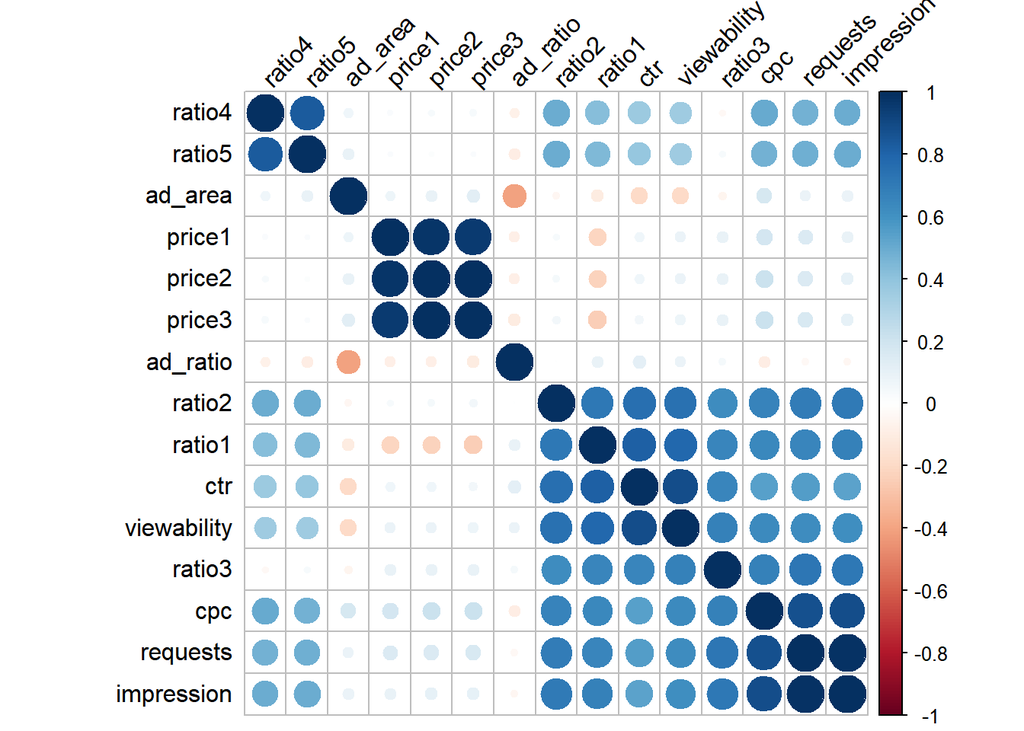

```r
corrplot(res, order = "hclust",
         tl.col = "black", tl.srt = 45)
```

Notable Correlations:

- Very strong positive correlation between Impression and Request of 0.99. These features are more or less redundant so only one will be included in the machine learning modelling.
- Very strong positive correlation between Price 1, Price 2 and Price 3. Additional analysis conducted below.
- Very strong positive correlation between CPC and Impression of 0.88.
- Very strong positive correlation between CTR and Viewability of 0.88.
- Very strong positive correlation between Ratio 4 and Ratio 5 of 0.83. Additional analysis conducted below.

```r
#Focus on correlation between price variables:
train_price <- train %>% select(price1,price2,price3)
res_price <- cor(train_price, method = "spearman")
round(res_price,2)
```

```
##        price1 price2 price3
## price1   1.00   0.97   0.96
## price2   0.97   1.00   0.99
## price3   0.96   0.99   1.00
```

Findings:

- Correlation between Price 1 and Price 2: 0.97
- Correlation between Price 2 and Price 3: 0.99
- Correlation between Price 3 and Price 1: 0.96

```r
#Focus on the correlation between ratio variables:
train_ratio <- train %>% select(ratio1, ratio2, ratio3, ratio4, ratio5)
res_ratio <- cor(train_ratio, method = "spearman")
round(res_ratio,2)
```

```
##        ratio1 ratio2 ratio3 ratio4 ratio5
## ratio1   1.00   0.72   0.66   0.42   0.44
## ratio2   0.72   1.00   0.62   0.50   0.50
## ratio3   0.66   0.62   1.00  -0.04   0.03
## ratio4   0.42   0.50  -0.04   1.00   0.83
## ratio5   0.44   0.50   0.03   0.83   1.00
```

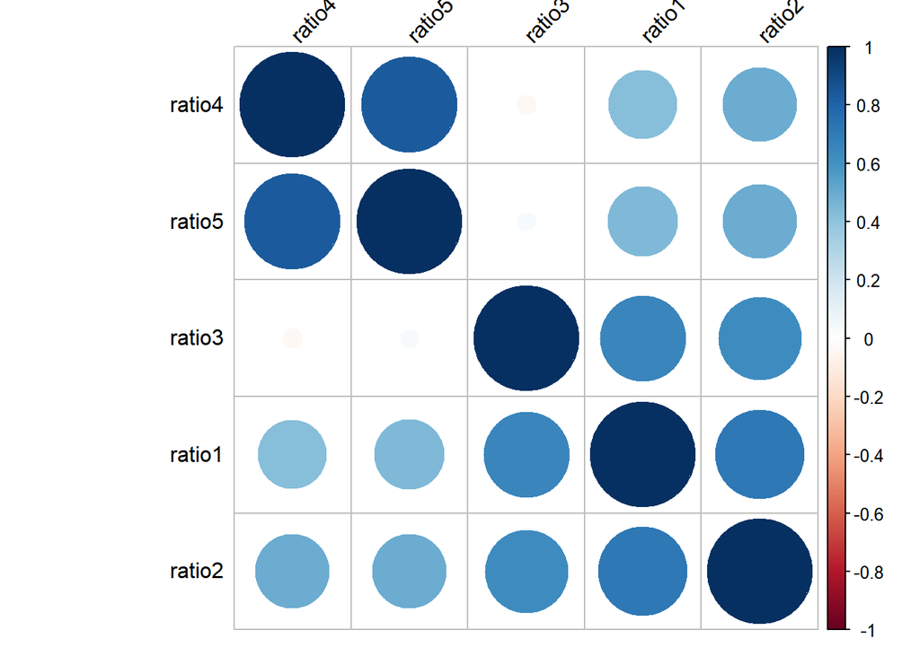

```r
corrplot(res_ratio, order = "hclust",
         tl.col = "black", tl.srt = 45)
```

Findings:

- Correlation between Ratio 4 and Ratio 5 is 0.83
- Correlation between Ratio 1 and Ratio 2 is 0.72
- Correlation between Ratio 1 and Ratio 3 is 0.66
- Correlation between Ratio 2 and Ratio 3 is 0.62
- All other ratio features have weaker correlation

The strong positive correlation between Ratio 4 and Ratio 5 raises the question as to whether both metrics are useful to conclude in the machine learning modelling.

The rest of the ratios exhibit a sufficiently weak correlation that we would want to initally include them in modelling.

```r
#Focus on the advertisement metrics data
train_metrics <- train %>% select(ad_area, ad_ratio, requests, impression, cpc, ctr, viewability)
res_metrics <- cor(train_metrics, method = "spearman")
round(res_metrics, 2)
```

```
##             ad_area ad_ratio requests impression   cpc   ctr viewability
## ad_area        1.00    -0.41     0.08       0.09  0.17 -0.19       -0.20
## ad_ratio      -0.41     1.00    -0.04      -0.04 -0.10  0.12        0.09
## requests       0.08    -0.04     1.00       0.99  0.88  0.55        0.63
## impression     0.09    -0.04     0.99       1.00  0.88  0.54        0.62
## cpc            0.17    -0.10     0.88       0.88  1.00  0.54        0.63
## ctr           -0.19     0.12     0.55       0.54  0.54  1.00        0.88
## viewability   -0.20     0.09     0.63       0.62  0.63  0.88        1.00
```

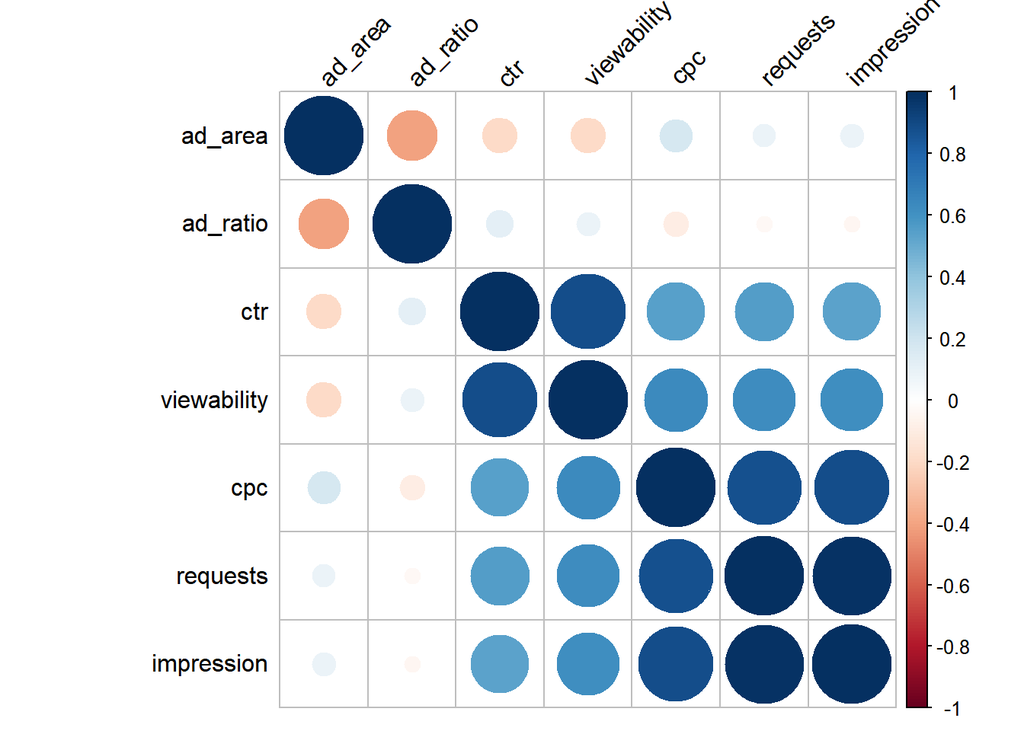

```r
corrplot(res_metrics, order = "hclust",
         tl.col = "black", tl.srt = 45)
```

Findings:

- Correlation between Impression and Requests is 0.99
- Correlation between Viewability and CTR is 0.88
- Correlation between CPC and Requests is 0.88
- Correlation between CPC and Impression is 0.88
- All other metrics have weak correlation

Given Impression and Requests are almost completely correlated, it is highly unlikely that we would want to include both features in our machine learning model.

```r
res_y <- cor(train$y,train_num, method = "spearman")
kable(round(res_y, 3))
```

| price1 | price2 | price3 | ad_area | ad_ratio | requests | impression | cpc | ctr | viewability | ratio1 | ratio2 | ratio3 | ratio4 | ratio5 |
| --- | --- | --- | --- | --- | --- | --- | --- | --- | --- | --- | --- | --- | --- | --- |
| 0.128 | 0.172 | 0.17 | 0.049 | -0.016 | -0.06 | -0.032 | 0.15 | 0.239 | 0.212 | 0.097 | 0.007 | 0.031 | 0.029 | -0.035 |

None of the descriptive features are highly correlated with the target feature y.

# Summary

The data set chosen for machine learning training is an advertising metrics data set provided by Google. First, we inspected the descriptive features and target feature in isolation. We noted that many of the descriptive features were zero for the majority of instances. We used a logarithmic transformation on the target feature (y) to improve the normality of its distribution. We then inspected the descriptive features with respect to the target feature y. We then took a closer look at the Price features and Ratio features, as well as two of the advertising metrics, Cost Per Click and Click Through Rate, in order to disaggregate instances with zero values and those with non-zero values. Finally, we calculated and inspected the correlation between the descriptive features and identified features that are likely to be redundant, and therefore of limited use to machine learning algorithm training.